# Regression Discontinuity Design

ChatGPT 4o

2025-01-21

## 1 起源

断点回归设计（Regression Discontinuity Design, RDD）起源于20世纪60年代，由Donald Thistlethwaite和Donald Campbell在研究奖学金项目对学生学业成就的影响时首次提出。RDD是一种准实验设计方法，广泛用于评估政策干预的因果效应，特别是在某种处理被分配基于明确的阈值或规则时。由于其直观和可靠性，RDD在经济学、教育学和公共政策评估中得到广泛应用。

## 2 原理

RDD的基本原理是利用分配变量（Running Variable）与阈值（Threshold）之间的关系来推断因果效应。当分配变量超过某个阈值时，个体接受处理，否则个体不接受处理。RDD的关键在于比较阈值附近的个体，通过这种方式推断因果效应。RDD可以分为两种类型：

1. **锐断型（Sharp RDD）**：当个体是否接受处理完全由分配变量是否超过阈值决定时，属于锐断型RDD。
2. **模糊型（Fuzzy RDD）**：当个体是否接受处理与分配变量超过阈值的概率相关时，属于模糊型RDD。

RDD的核心假设是**连续性假设**，即在阈值附近，处理组和对照组的个体在未接受处理的情况下应具有相同的趋势。通过比较阈值附近的个体，可以推断出处理的因果效应。

RDD模型的数学表达式为：
$$Y_i = \alpha + \tau D_i + f(X_i) + \epsilon_i$$
其中： - $Y_i$ 为因变量，表示个体的结果； - $D_i$ 为处理指示变量（当分配变量超过阈值时为1，否则为0）； - $f(X_i)$ 为分配变量的函数，用于捕捉分配变量对结果的影响； - $\tau$ 为因果效应的估计值。

## 3 适用范围

RDD适用于以下情况：

- **明确的阈值规则**：当处理的分配基于明确的阈值或规则时，RDD是合适的选择。
- **政策评估**：当政策干预的实施是基于特定的分数或指标（如考试成绩、年龄）时，可以使用RDD来评估其效果。
- **自然实验**：当无法进行随机分配时，RDD提供了一种准实验的替代方法。

## 4 应用情境

RDD方法在多个领域中有广泛的应用，例如：

- **教育学**：用于评估奖学金、补习班等教育干预措施对学生学业成绩的影响，当干预是基于特定成绩的阈值时。
- **公共政策**：用于评估社会福利、医疗补助等政策对受益者的影响，例如基于收入阈值分配福利。
- **医学和公共卫生**：用于评估基于年龄、体重等阈值进行的健康干预措施的效果。
- **经济学**：用于分析税收政策、补贴政策等对个体经济行为的影响。

## 5 优缺点

### 优点

- **因果推断可靠**：RDD通过阈值附近的个体比较，能够有效推断因果效应，减少混杂偏倚。
- **直观易于解释**：RDD方法直观，基于阈值规则的处理分配使其易于理解和解释。
- **接近随机实验**：在阈值附近，RDD的处理和对照组可以被视为随机分配，具有接近随机对照试验的效果。

### 缺点

- **样本量要求高**：RDD仅利用阈值附近的样本进行分析，因此对样本量要求较高。
- **阈值选择敏感**：RDD的结果对阈值的选择较为敏感，可能会影响估计的稳定性。
- **外部效度有限**：RDD只能推断阈值附近的因果效应，无法推广到整个样本。

## 6 在R中的实现及结果解释

在R中，可以使用`rdrobust`包来实现RDD分析，以下是一个实现RDD的示例：

```r
# 加载必要的包
library(rdrobust)
library(ggplot2)

# 示例数据：生成假设的分配变量和结果变量数据
set.seed(123)
data <- data.frame(
  running_var = runif(200, min = 0, max = 100),
  outcome = rnorm(200, mean = 50, sd = 10)
)

# 创建阈值并生成处理指示变量
data$treat <- ifelse(data$running_var > 50, 1, 0)
data$outcome <- data$outcome + data$treat * 10  # 假设处理效果为增加10个单位

# 进行RDD分析
rdd_result <- rdrobust(y = data$outcome, x = data$running_var, c = 50)
summary(rdd_result)
```

```
## Sharp RD estimates using local polynomial regression.
##
## Number of Obs.                  200
## BW type                       mserd
## Kernel                   Triangular
## VCE method                       NN
##
## Number of Obs.                  103           97
## Eff. Number of Obs.              26           19
## Order est. (p)                    1            1
## Order bias  (q)                   2            2
## BW est. (h)                  10.102       10.102
## BW bias (b)                  16.852       16.852
## rho (h/b)                     0.599        0.599
## Unique Obs.                     103           97
##
## =============================================================================
##         Method     Coef. Std. Err.         z     P>|z|      [ 95% C.I. ]
## =============================================================================
##   Conventional     4.172     3.820     1.092     0.275    [-3.316 , 11.659]
##         Robust         -         -     0.617     0.537    [-6.075 , 11.663]
## =============================================================================
```

```r
str(rdd_result)
```

[output not shown]

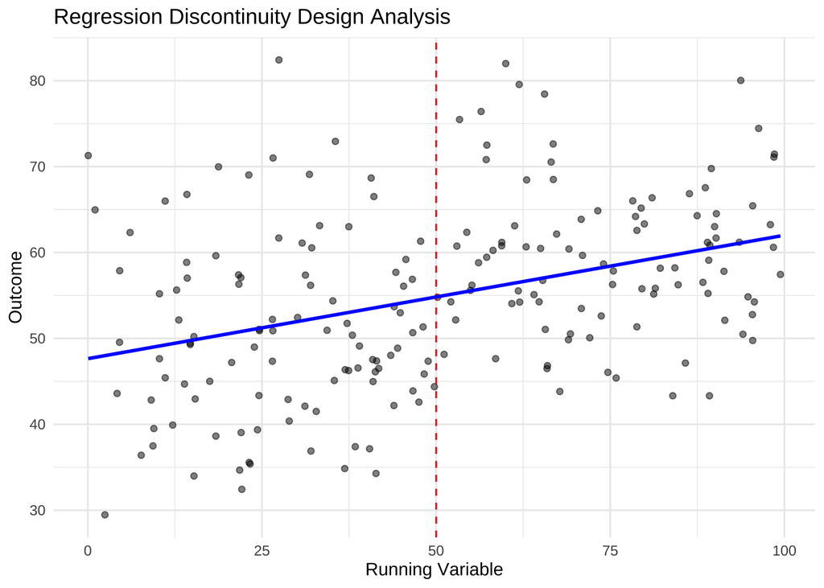

```r
# 可视化：绘制RDD的散点图和拟合线
ggplot(data, aes(x = running_var, y = outcome)) +
  geom_point(alpha = 0.5) +
  geom_vline(xintercept = 50, linetype = "dashed", color = "red") +
  geom_smooth(method = "lm", formula = y ~ poly(x, 1), se = FALSE, color = "blue") +
  labs(title = "Regression Discontinuity Design Analysis", x = "Running Variable", y = "Outcome") +
  theme_minimal()
```

### 结果的可视化

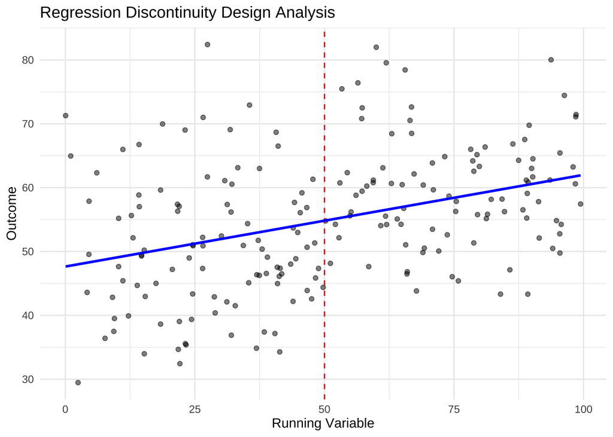

```r
# 使用ggplot2包绘制分配变量与结果变量的关系图
ggplot(data, aes(x = running_var, y = outcome)) +
  geom_point(alpha = 0.5) +
  geom_vline(xintercept = 50, linetype = "dashed", color = "red") +
  geom_smooth(method = "lm", formula = y ~ poly(x, 1), se = FALSE, color = "blue") +
  labs(title = "Regression Discontinuity Design Analysis", x = "Running Variable", y = "Outcome") +
  theme_minimal()
```